# Introducción al análisis de datos con R: Clase 4

### Variables cuantitativas

Indaguemos ahora la estructura de las **variables numéricas**:

## Quantile()

Los **cuartiles** pueden calcularse con `quantile()`:

```r
#Cantidad de divorcios por año
divorcio_anual <- df_divorcios %>%
                      group_by(ANIO_CREACION) %>%
                          summarise(total = n())

#Cuartiles
quantile(divorcio_anual$total, prob = c(0.25, 0.5, 0.75, 1), na.rm = TRUE)
```

```
##    25%    50%    75%   100%
## 2686.0 4081.0 6382.5 7050.0
```

```r
# Deciles
quantile(divorcio_anual$total, prob = seq(0,1, length=11), na.rm = TRUE)
```

```
##     0%    10%    20%    30%    40%    50%    60%    70%    80%    90%   100%
##    6.0   34.0 1454.0 3570.3 3600.4 4081.0 4908.4 6152.3 6456.0 6693.0 7050.0
```

```r
# Percentiles
quantile(divorcio_anual$total, prob = seq(0,1, length=101), na.rm = TRUE)
```

```
##      0%      1%      2%      3%      4%      5%      6%      7%      8%      9%
##    6.00    8.80   11.60   14.40   17.20   20.00   22.80   25.60   28.40   31.20
##     10%     11%     12%     13%     14%     15%     16%     17%     18%     19%
##   34.00   36.80   39.60   42.40   45.20  222.00  468.40  714.80  961.20 1207.60
##     20%     21%     22%     23%     24%     25%     26%     27%     28%     29%
## 1454.00 1700.40 1946.80 2193.20 2439.60 2686.00 2932.40 3178.80 3425.20 3567.29
##     30%     31%     32%     33%     34%     35%     36%     37%     38%     39%
## 3570.30 3573.31 3576.32 3579.33 3582.34 3585.35 3588.36 3591.37 3594.38 3597.39
##     40%     41%     42%     43%     44%     45%     46%     47%     48%     49%
## 3600.40 3603.41 3606.42 3618.44 3684.52 3750.60 3816.68 3882.76 3948.84 4014.92
##     50%     51%     52%     53%     54%     55%     56%     57%     58%     59%
## 4081.00 4147.08 4213.16 4279.24 4345.32 4411.40 4477.48 4543.56 4659.62 4784.01
##     60%     61%     62%     63%     64%     65%     66%     67%     68%     69%
## 4908.40 5032.79 5157.18 5281.57 5405.96 5530.35 5654.74 5779.13 5903.52 6027.91
##     70%     71%     72%     73%     74%     75%     76%     77%     78%     79%
## 6152.30 6276.69 6338.40 6353.10 6367.80 6382.50 6397.20 6411.90 6426.60 6441.30
##     80%     81%     82%     83%     84%     85%     86%     87%     88%     89%
## 6456.00 6470.70 6485.40 6500.10 6514.80 6529.50 6550.20 6585.90 6621.60 6657.30
##     90%     91%     92%     93%     94%     95%     96%     97%     98%     99%
## 6693.00 6728.70 6764.40 6800.10 6835.80 6871.50 6907.20 6942.90 6978.60 7014.30
##    100%
## 7050.00
```

En el 50% de los años registrados hubo, al menos, más de 4081 divorcios.

## Mean()

Podemos calcular el **promedio** de divorcios con `mean()`:

```r
mean(divorcio_anual$total)
```

```
## [1] 3962.5
```

Entre el 2015 y el 2022 se registra un promedio anual de 3963 divorcios.

## Sd() y Var()

La **desviación estándar** de esta distribución se puede calcular con `sd()` y la **varianza** con `var()`:

```r
(sd(divorcio_anual$total,
     na.rm = TRUE))
```

```
## [1] 2762.115
```

```r
(var(divorcio_anual$total,
    na.rm = T))
```

```
## [1] 7629278
```

Además, podemos recurrir a `summary()` que proporciona un resumen de las **medidas de posición** de las variables numéricas:

```r
#RECAP clase 3:
#Creamos el vector de las variables que modificaremos:
variables_numericas <- c("DIA_CREACION", "ANIO_CREACION", "DIA_MAT", "ANIO_MAT")
#aplicamos la función as.numeric() con lapply()
df_divorcios[, variables_numericas] <- lapply(X = df_divorcios[, variables_numericas],
                                                FUN = as.numeric)

#summary()
summary(df_divorcios[, variables_numericas])
```

```
##   DIA_CREACION   ANIO_CREACION     DIA_MAT         ANIO_MAT
##  Min.   : 1.00   Min.   :2015   Min.   : 1.00   Min.   :1931
##  1st Qu.: 8.00   1st Qu.:2018   1st Qu.: 8.00   1st Qu.:1992
##  Median :15.00   Median :2019   Median :15.00   Median :2002
##  Mean   :15.52   Mean   :2020   Mean   :15.36   Mean   :2000
##  3rd Qu.:23.00   3rd Qu.:2021   3rd Qu.:23.00   3rd Qu.:2010
##  Max.   :31.00   Max.   :2022   Max.   :31.00   Max.   :3201
##                                 NA's   :737     NA's   :737
```

Podemos calcular la cantidad de años de casados de cada caso, creando una nueva variable, y obtener su resumen:

```r
df_divorcios <- df_divorcios %>%
  mutate(anios_casados = ANIO_CREACION - ANIO_MAT)

#resumen
summary(df_divorcios$anios_casados)
```

```
##     Min.  1st Qu.   Median     Mean  3rd Qu.     Max.     NA's
## -1182.00     9.00    17.00    19.16    27.00    89.00      737
```

```r
# puedo construir mi propia resumen
resumen <- df_divorcios %>% summarise(promedio = mean(anios_casados, na.rm=T),
                                      mediana = median(anios_casados, na.rm=T))

resumen
```

```
## # A tibble: 1 × 2
##   promedio mediana
##      <dbl>   <dbl>
## 1     19.2      17
```

## Boxplot () y Hist()

Se puede ver que -aunque estan próximas- la **mediana** < **media**, lo que evidencia un sesgo hacia la derecha (valores máximos).Esto puede quedar más claro con un **boxplot** mediante la función `boxplot()` o un histograma con `hist()`, ambos de R base:

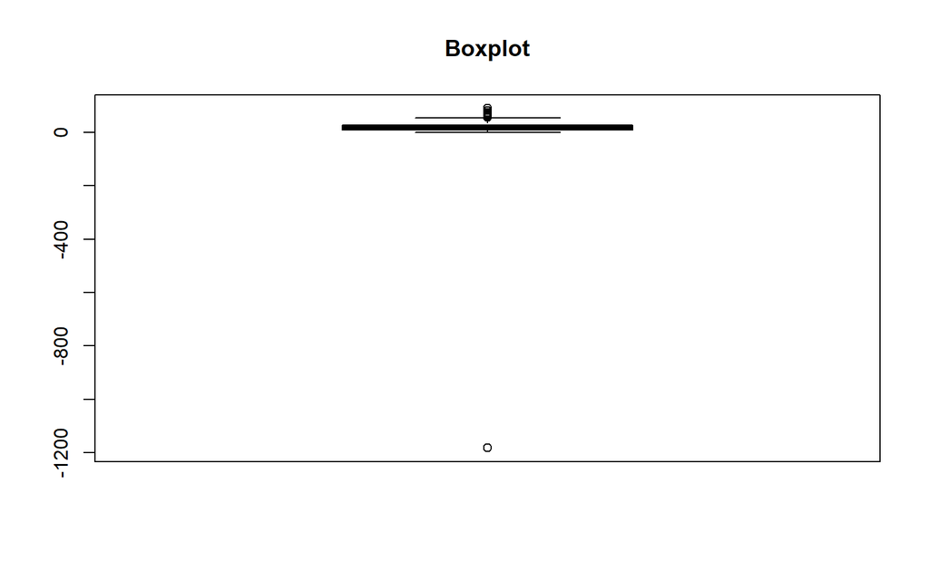

```r
#boxplot
boxplot(df_divorcios$anios_casados,
        #título del gráfico
        main = "Boxplot")
```

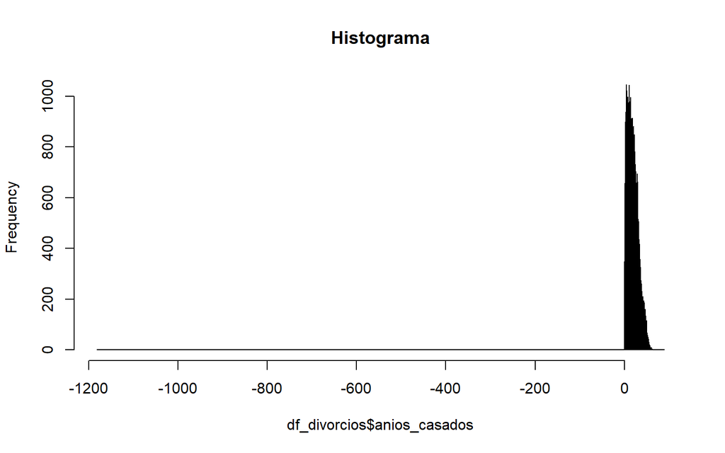

```r
#histograma
hist(df_divorcios$anios_casados,
     #cortes
     breaks = 10000,
     main = "Histograma")
```

En ambos gráficos podemos notar la existencia de **valores atípicos** que afectan la distribución de la variable. Con los datos del boxplot, podremos saber cuáles son estos valores (caen por fuera de los umbrales):

```r
#cuartiles
summary(df_divorcios$anios_casados)
```

```
##     Min.  1st Qu.   Median     Mean  3rd Qu.     Max.     NA's
## -1182.00     9.00    17.00    19.16    27.00    89.00      737
```

```r
#rango intercuartil (q3 - q1): centro del boxplot: 27-9
IQR(df_divorcios$anios_casados, na.rm = T)
```

```
## [1] 18
```

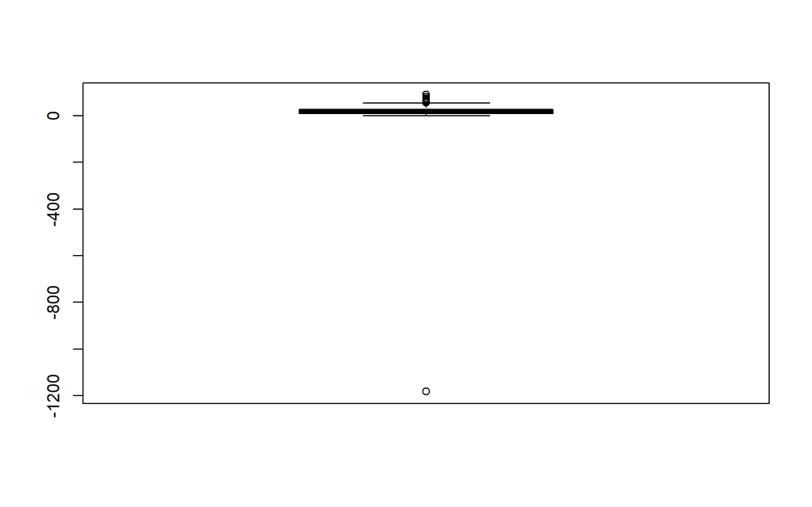

```r
#valores que caen por fuera de (umbral máximo: 27 + 1.5 = 28.5) y (umbral mínimo: 9 - 1.5= 7.5)
outliers <- boxplot(df_divorcios$anios_casados)$out %>% as.data.frame()
```

```r
outliers
```

```
##         .
## 1      68
## 2      61
## 3      55
## 4      61
## 5      61
## 6      55
## 7      56
## 8      68
## 9      57
## 10     60
## 11     56
## 12     64
## 13     58
## 14     81
```

[output cut: 116 more lines]

```r
df_sin_outliers <- df_divorcios %>%
                    filter(between(anios_casados, 7.5, 28.5))

#chequeamos distribución
table(df_sin_outliers$anios_casados)
```

```
##
##    8    9   10   11   12   13   14   15   16   17   18   19   20   21   22   23
##  997  911  975 1044  939  978  996  912  880  914  914  848  880  786  773  849
##   24   25   26   27   28
##  781  731  703  650  659
```

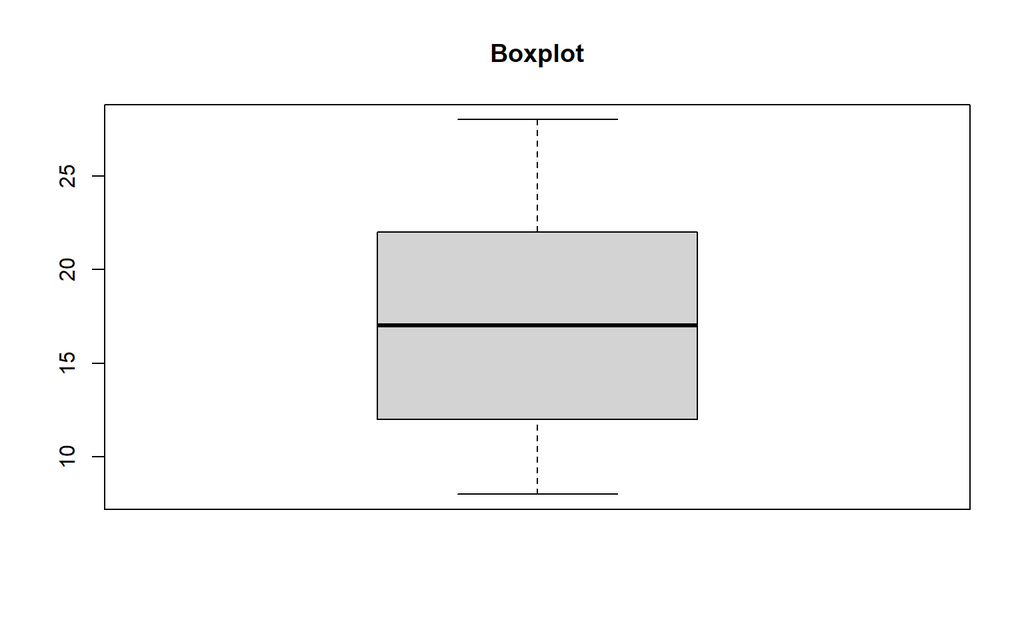

```r
#probamos realizar nuevamente el gráfico
boxplot(df_sin_outliers$anios_casados,
        main = "Boxplot")
```

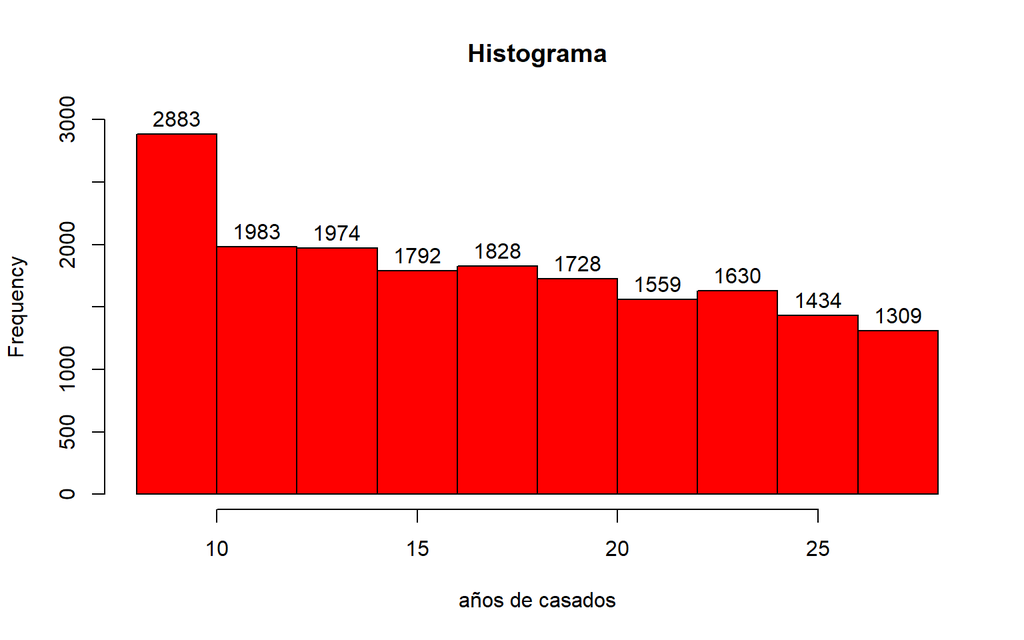

```r
#paprovechemos a jugar un poco customizando estos gráficos
hist(df_sin_outliers$anios_casados,
     breaks = 10, #cortes
     main = "Histograma", #titulo
     col = 'red', #color
     border = 'black', #border color
     labels = TRUE, #agregamos etiquetas a cada barra
     ylim = c(0,3000), #definimos los umbrales del eje y
     xlab  =  "años de casados" #definimos titulo del eje
     )
```

Podríamos chequear los nuevos valores extremos. Para acceder al valor máximo lo hacemos con `filter()` y `max()`:

```r
df_sin_outliers %>%
  filter(anios_casados == max(anios_casados))
```

```
## # A tibble: 659 × 12
##    FECHA…¹ GENER…² GENER…³ FECHA…⁴ ...5  DIA_C…⁵ MES_C…⁶ ANIO_…⁷ DIA_MAT MES_MAT
##    <chr>   <chr>   <chr>   <chr>   <lgl>   <dbl> <chr>     <dbl>   <dbl> <chr>
##  1 15MAR2… No dec… No dec… 12FEB1… NA         15 MAR        2018      12 FEB
##  2 07MAR2… No dec… Femeni… 20APR1… NA          7 MAR        2018      20 APR
##  3 21MAR2… Mascul… Femeni… 08OCT1… NA         21 MAR        2018       8 OCT
##  4 21MAR2… No dec… No dec… 24AUG1… NA         21 MAR        2018      24 AUG
##  5 22MAR2… No dec… No dec… 09MAR1… NA         22 MAR        2018       9 MAR
##  6 07MAR2… No dec… No dec… 24MAY1… NA          7 MAR        2018      24 MAY
##  7 09MAR2… No dec… No dec… 08JUN1… NA          9 MAR        2018       8 JUN
##  8 14MAR2… No dec… No dec… 12JUL1… NA         14 MAR        2018      12 JUL
##  9 19MAR2… No dec… No dec… 06APR1… NA         19 MAR        2018       6 APR
## 10 19MAR2… No dec… No dec… 07DEC1… NA         19 MAR        2018       7 DEC
## # … with 649 more rows, 2 more variables: ANIO_MAT <dbl>, anios_casados <dbl>,
## #   and abbreviated variable names ¹FECHA_CREACION, ²GENERO_1, ³GENERO_2,
## #   ⁴FECHA_MATRIMONIO, ⁵DIA_CREACION, ⁶MES_CREACION, ⁷ANIO_CREACION
```

```r
#659 casos que registran la mayor cantidad de años de casadxs
```

Valor mínimo con `min()`:

```r
(minimos <- df_sin_outliers %>%
  filter(anios_casados == min(anios_casados)))
```

```
## # A tibble: 997 × 12
##    FECHA…¹ GENER…² GENER…³ FECHA…⁴ ...5  DIA_C…⁵ MES_C…⁶ ANIO_…⁷ DIA_MAT MES_MAT
##    <chr>   <chr>   <chr>   <chr>   <lgl>   <dbl> <chr>     <dbl>   <dbl> <chr>
##  1 20MAR2… Mascul… Femeni… 07OCT2… NA         20 MAR        2018       7 OCT
##  2 05MAR2… Mascul… Femeni… 25JUN2… NA          5 MAR        2018      25 JUN
##  3 13MAR2… Mascul… Femeni… 19NOV2… NA         13 MAR        2018      19 NOV
##  4 21MAR2… Mascul… Femeni… 15APR2… NA         21 MAR        2018      15 APR
##  5 05MAR2… Mascul… Femeni… 13APR2… NA          5 MAR        2018      13 APR
##  6 05MAR2… Mascul… Femeni… 18OCT2… NA          5 MAR        2018      18 OCT
##  7 05MAR2… Mascul… Femeni… 10DEC2… NA          5 MAR        2018      10 DEC
##  8 21MAR2… Mascul… Femeni… 02MAR2… NA         21 MAR        2018       2 MAR
##  9 12MAR2… Mascul… Femeni… 01DEC2… NA         12 MAR        2018       1 DEC
## 10 16MAR2… Mascul… Femeni… 23MAR2… NA         16 MAR        2018      23 MAR
## # … with 987 more rows, 2 more variables: ANIO_MAT <dbl>, anios_casados <dbl>,
## #   and abbreviated variable names ¹FECHA_CREACION, ²GENERO_1, ³GENERO_2,
## #   ⁴FECHA_MATRIMONIO, ⁵DIA_CREACION, ⁶MES_CREACION, ⁷ANIO_CREACION
```

```r
#997 casos con 8 años de casadxs
```

## YAPA: reportes estadísticos

Para obtener resúmenes estadísticos, pueden probar con la función `skim()` del paquete Skimr, con `Desc()` del paquete DesTools, o con `create_report()` del paquete DataExplorer:

```r
# install.packages("skimr")
library(skimr)

#se obtiene  un tibble por tipo de variables
tabla <- skim(df_divorcios)
tabla
```

Data summary

| Name | df_divorcios |
| --- | --- |
| Number of rows | 31700 |
| Number of columns | 12 |
| _______________________ |  |
| Column type frequency: |  |
| character | 6 |
| logical | 1 |
| numeric | 5 |
| ________________________ |  |
| Group variables | None |

**Variable type: character**

| skim_variable | n_missing | complete_rate | min | max | empty | n_unique | whitespace |
| --- | --- | --- | --- | --- | --- | --- | --- |
| FECHA_CREACION | 0 | 1.00 | 18 | 18 | 0 | 31674 | 0 |
| GENERO_1 | 2573 | 0.92 | 8 | 10 | 0 | 4 | 0 |
| GENERO_2 | 2549 | 0.92 | 1 | 10 | 0 | 5 | 0 |
| FECHA_MATRIMONIO | 737 | 0.98 | 18 | 18 | 0 | 9070 | 0 |
| MES_CREACION | 0 | 1.00 | 3 | 3 | 0 | 12 | 0 |
| MES_MAT | 737 | 0.98 | 3 | 3 | 0 | 12 | 0 |

**Variable type: logical**

| skim_variable | n_missing | complete_rate | mean | count |
| --- | --- | --- | --- | --- |
| …5 | 31700 | 0 | NaN | : |

**Variable type: numeric**

| skim_variable | n_missing | complete_rate | mean | sd | p0 | p25 | p50 | p75 | p100 | hist |
| --- | --- | --- | --- | --- | --- | --- | --- | --- | --- | --- |
| DIA_CREACION | 0 | 1.00 | 15.52 | 8.72 | 1 | 8 | 15 | 23 | 31 | ▇▇▆▆▆ |
| ANIO_CREACION | 0 | 1.00 | 2019.50 | 1.63 | 2015 | 2018 | 2019 | 2021 | 2022 | ▁▂▇▂▆ |
| DIA_MAT | 737 | 0.98 | 15.36 | 8.60 | 1 | 8 | 15 | 23 | 31 | ▇▆▇▆▆ |
| ANIO_MAT | 737 | 0.98 | 2000.36 | 14.02 | 1931 | 1992 | 2002 | 2010 | 3201 | ▇▁▁▁▁ |
| anios_casados | 737 | 0.98 | 19.16 | 13.96 | -1182 | 9 | 17 | 27 | 89 | ▁▁▁▁▇ |

```r
# install.packages("DescTools")
library(DescTools)

#resumen descriptivo
Desc(df_divorcios)
```

```
## ------------------------------------------------------------------------------
## Describe df_divorcios (tbl_df, tbl, data.frame):
##
## data frame:  31700 obs. of  12 variables
##      0 complete cases (0.0%)
##
##   Nr  ColName           Class      NAs             Levels
##   1   FECHA_CREACION    character      .
##   2   GENERO_1          character   2573 (8.1%)
##   3   GENERO_2          character   2549 (8.0%)
##   4   FECHA_MATRIMONIO  character    737 (2.3%)
##   5   ...5              logical    31700 (100.0%)
##   6   DIA_CREACION      numeric        .
##   7   MES_CREACION      character      .
##   8   ANIO_CREACION     numeric        .
##   9   DIA_MAT           numeric      737 (2.3%)
##   10  MES_MAT           character    737 (2.3%)
##   11  ANIO_MAT          numeric      737 (2.3%)
##   12  anios_casados     numeric      737 (2.3%)
##
##
## ------------------------------------------------------------------------------
## 1 - FECHA_CREACION (character)
##
##   length      n    NAs unique levels  dupes
##   31'700 31'700      0 31'674 31'674      y
##          100.0%   0.0%
##
##                  level  freq  perc  cumfreq  cumperc
## 1   01MAR2019:09:24:24     2  0.0%        2     0.0%
## 2   02JAN2018:09:41:47     2  0.0%        4     0.0%
## 3   02OCT2017:08:58:28     2  0.0%        6     0.0%
## 4   03DEC2018:10:05:37     2  0.0%        8     0.0%
## 5   06MAY2019:12:10:07     2  0.0%       10     0.0%
## 6   06MAY2021:11:46:37     2  0.0%       12     0.0%
## 7   07DEC2017:09:30:58     2  0.0%       14     0.0%
## 8   08JAN2020:08:37:49     2  0.0%       16     0.1%
## 9   09APR2018:08:58:29     2  0.0%       18     0.1%
## 10  09NOV2018:07:20:51     2  0.0%       20     0.1%
## 11  09OCT2017:08:40:44     2  0.0%       22     0.1%
## 12  15DEC2017:09:24:19     2  0.0%       24     0.1%
## ... etc.
##  [list output truncated]
```

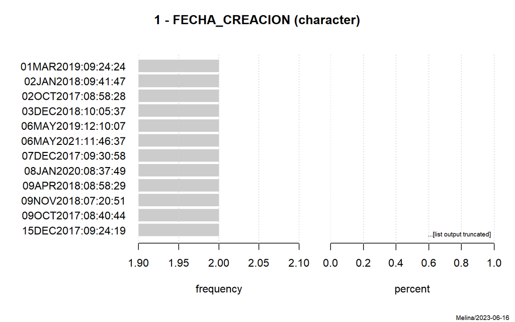

```
## ------------------------------------------------------------------------------
## 2 - GENERO_1 (character)
##
##   length      n    NAs unique levels  dupes
##   31'700 29'127  2'573      4      4      y
##           91.9%   8.1%
##
##         level    freq   perc  cumfreq  cumperc
## 1   Masculino  23'220  79.7%   23'220    79.7%
## 2  No declara   4'668  16.0%   27'888    95.7%
## 3    Femenino   1'204   4.1%   29'092    99.9%
## 4  Indefinido      35   0.1%   29'127   100.0%
```

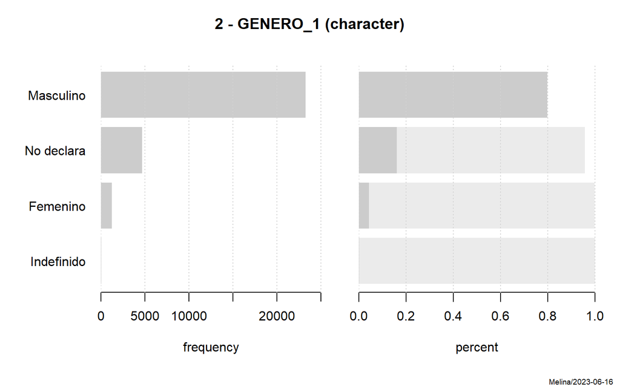

```
## ------------------------------------------------------------------------------
## 3 - GENERO_2 (character)
##
##   length      n    NAs unique levels  dupes
##   31'700 29'151  2'549      5      5      y
##           92.0%   8.0%
##
##         level    freq   perc  cumfreq  cumperc
## 1    Femenino  23'211  79.6%   23'211    79.6%
## 2  No declara   4'648  15.9%   27'859    95.6%
## 3   Masculino   1'246   4.3%   29'105    99.8%
## 4  Indefinido      45   0.2%   29'150   100.0%
## 5           X       1   0.0%   29'151   100.0%
```

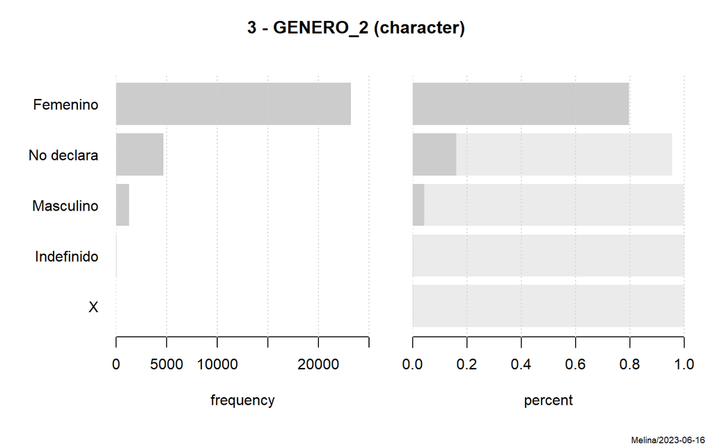

```
## ------------------------------------------------------------------------------
## 4 - FECHA_MATRIMONIO (character)
##
##   length      n    NAs unique levels  dupes
##   31'700 30'963    737  9'070  9'070      y
##           97.7%   2.3%
##
##                  level  freq  perc  cumfreq  cumperc
## 1   03DEC2010:00:00:00    28  0.1%       28     0.1%
## 2   01DEC2000:00:00:00    22  0.1%       50     0.2%
## 3   17DEC2010:00:00:00    22  0.1%       72     0.2%
## 4   18DEC1992:00:00:00    21  0.1%       93     0.3%
## 5   03MAR2000:00:00:00    20  0.1%      113     0.4%
## 6   03NOV2006:00:00:00    20  0.1%      133     0.4%
## 7   09DEC1999:00:00:00    20  0.1%      153     0.5%
## 8   09DEC2005:00:00:00    20  0.1%      173     0.6%
## 9   10DEC2010:00:00:00    20  0.1%      193     0.6%
## 10  11DEC2009:00:00:00    20  0.1%      213     0.7%
## 11  24NOV2000:00:00:00    20  0.1%      233     0.8%
## 12  28NOV2003:00:00:00    20  0.1%      253     0.8%
## ... etc.
##  [list output truncated]
```

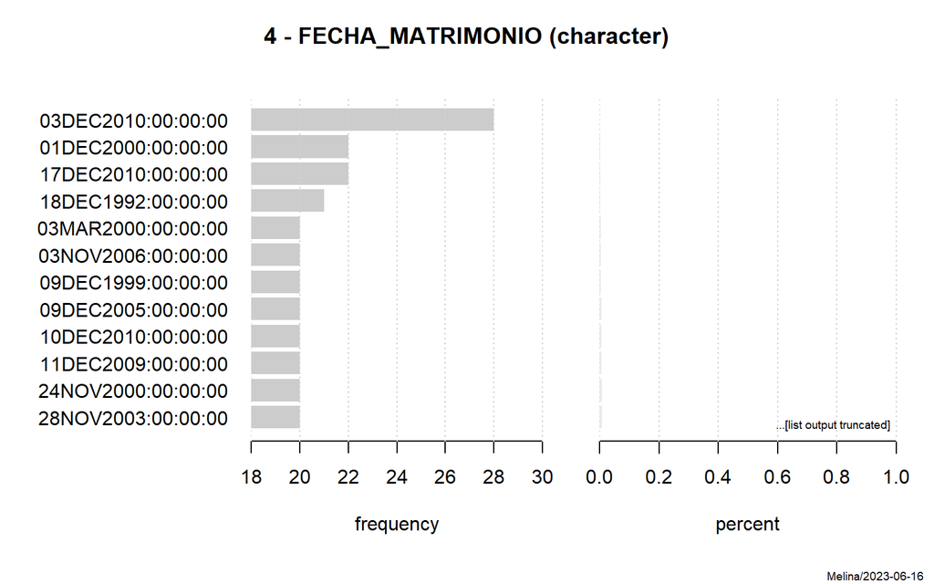

```
## ------------------------------------------------------------------------------
## 5 - ...5 (logical)
##
##   length      n    NAs unique
##   31'700      0 31'700 NA
##            0.0% 100.0%
##
## Nothing to plot in ...5
##
## ------------------------------------------------------------------------------
## 6 - DIA_CREACION (numeric)
##
##   length       n    NAs  unique     0s   mean  meanCI'
##   31'700  31'700      0      31      0  15.52   15.43
##           100.0%   0.0%           0.0%          15.62
##
##      .05     .10    .25  median    .75    .90     .95
##     2.00    4.00   8.00   15.00  23.00  28.00   29.00
##
##    range      sd  vcoef     mad    IQR   skew    kurt
##    30.00    8.72   0.56   11.86  15.00   0.06   -1.20
##
## lowest : 1.0 (900), 2.0 (1'010), 3.0 (1'074), 4.0 (1'042), 5.0 (1'211)
## highest: 27.0 (1'124), 28.0 (1'033), 29.0 (987), 30.0 (952), 31.0 (423)
##
## ' 95%-CI (classic)
```

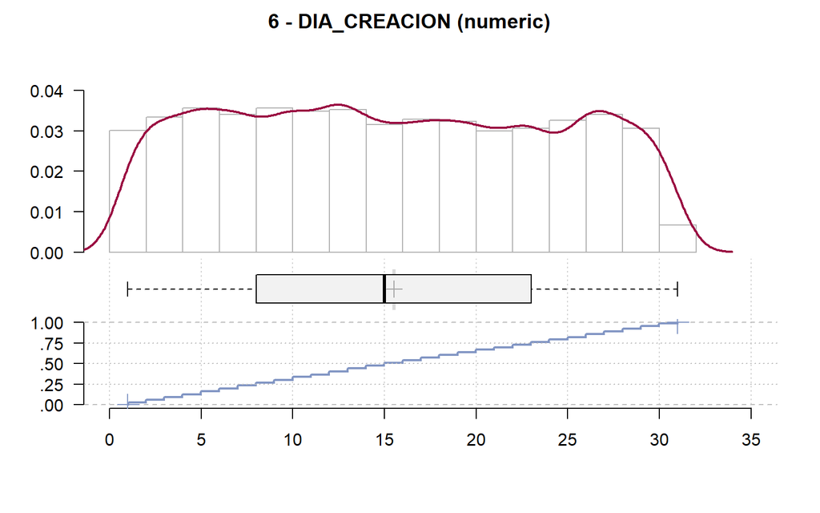

```
## ------------------------------------------------------------------------------
## 7 - MES_CREACION (character)
##
##   length      n    NAs unique levels  dupes
##   31'700 31'700      0     12     12      y
##          100.0%   0.0%
##
##     level   freq   perc  cumfreq  cumperc
## 1     DEC  3'658  11.5%    3'658    11.5%
## 2     NOV  3'502  11.0%    7'160    22.6%
## 3     MAR  3'135   9.9%   10'295    32.5%
## 4     OCT  3'036   9.6%   13'331    42.1%
## 5     AUG  2'592   8.2%   15'923    50.2%
## 6     SEP  2'589   8.2%   18'512    58.4%
## 7     MAY  2'573   8.1%   21'085    66.5%
## 8     APR  2'441   7.7%   23'526    74.2%
## 9     FEB  2'387   7.5%   25'913    81.7%
## 10    JUN  2'324   7.3%   28'237    89.1%
## 11    JUL  2'109   6.7%   30'346    95.7%
## 12    JAN  1'354   4.3%   31'700   100.0%
```

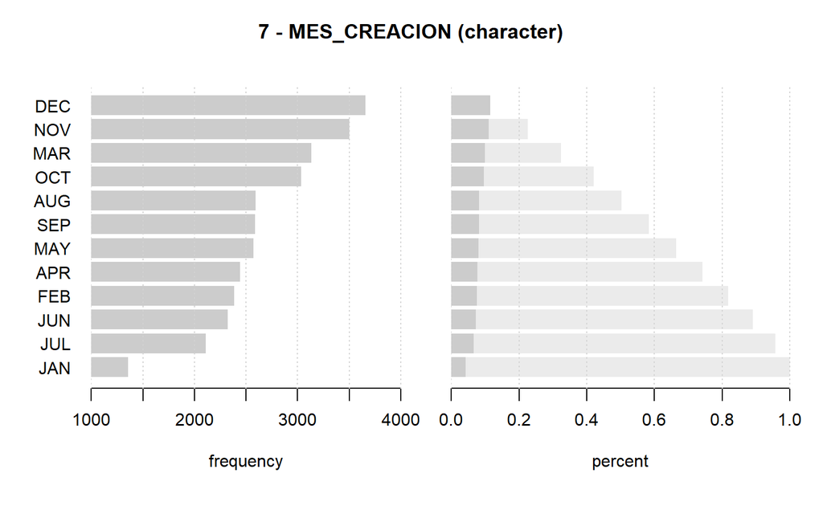

```
## ------------------------------------------------------------------------------
## 8 - ANIO_CREACION (numeric)
##
##     length         n       NAs    unique        0s      mean    meanCI'
##     31'700    31'700         0         8         0  2'019.50  2'019.49
##               100.0%      0.0%                0.0%            2'019.52
##
##        .05       .10       .25    median       .75       .90       .95
##   2'017.00  2'017.00  2'018.00  2'019.00  2'021.00  2'022.00  2'022.00
##
##      range        sd     vcoef       mad       IQR      skew      kurt
##       7.00      1.63      0.00      1.48      3.00      0.07     -1.24
##
##
##    value   freq   perc  cumfreq  cumperc
## 1   2015      6   0.0%        6     0.0%
## 2   2016     46   0.1%       52     0.2%
## 3   2017  3'566  11.2%    3'618    11.4%
## 4   2018  7'050  22.2%   10'668    33.7%
## 5   2019  6'330  20.0%   16'998    53.6%
## 6   2020  3'609  11.4%   20'607    65.0%
## 7   2021  6'540  20.6%   27'147    85.6%
## 8   2022  4'553  14.4%   31'700   100.0%
##
## ' 95%-CI (classic)
```

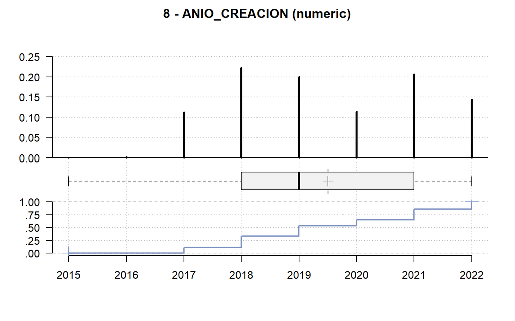

```
## ------------------------------------------------------------------------------
## 9 - DIA_MAT (numeric)
##
##   length       n    NAs  unique     0s   mean  meanCI'
##   31'700  30'963    737      31      0  15.36   15.26
##            97.7%   2.3%           0.0%          15.45
##
##      .05     .10    .25  median    .75    .90     .95
##     2.00    4.00   8.00   15.00  23.00  27.00   29.00
##
##    range      sd  vcoef     mad    IQR   skew    kurt
##    30.00    8.60   0.56   10.38  15.00   0.05   -1.16
##
## lowest : 1.0 (955), 2.0 (986), 3.0 (1'019), 4.0 (1'075), 5.0 (1'083)
## highest: 27.0 (980), 28.0 (941), 29.0 (793), 30.0 (865), 31.0 (409)
##
## ' 95%-CI (classic)
```

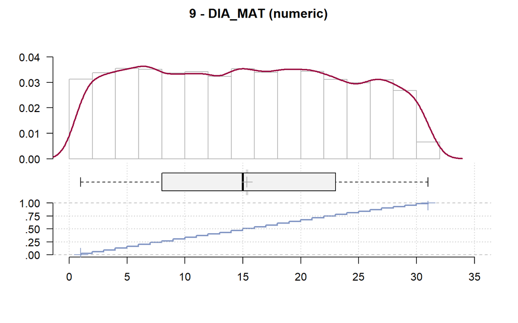

```
## ------------------------------------------------------------------------------
## 10 - MES_MAT (character)
##
##   length      n    NAs unique levels  dupes
##   31'700 30'963    737     12     12      y
##           97.7%   2.3%
##
##     level   freq   perc  cumfreq  cumperc
## 1     DEC  3'770  12.2%    3'770    12.2%
## 2     NOV  3'606  11.6%    7'376    23.8%
## 3     MAR  3'600  11.6%   10'976    35.4%
## 4     APR  2'796   9.0%   13'772    44.5%
## 5     OCT  2'748   8.9%   16'520    53.4%
## 6     SEP  2'676   8.6%   19'196    62.0%
## 7     FEB  2'193   7.1%   21'389    69.1%
## 8     JAN  2'132   6.9%   23'521    76.0%
## 9     JUL  1'974   6.4%   25'495    82.3%
## 10    MAY  1'972   6.4%   27'467    88.7%
## 11    AUG  1'909   6.2%   29'376    94.9%
## 12    JUN  1'587   5.1%   30'963   100.0%
```

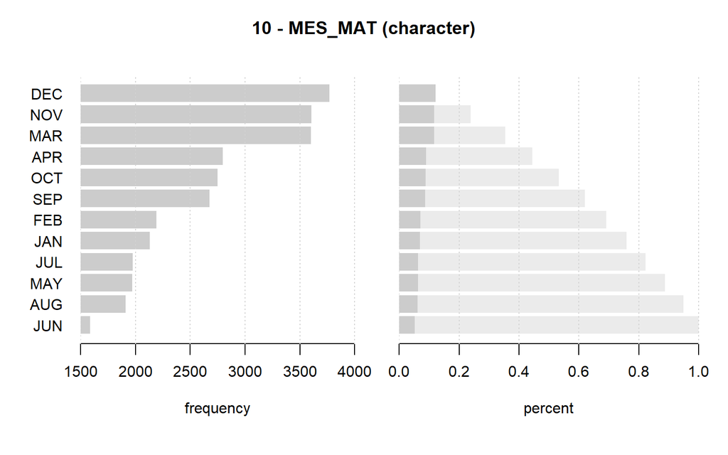

```
## ------------------------------------------------------------------------------
## 11 - ANIO_MAT (numeric)
##
##     length         n       NAs    unique        0s      mean    meanCI'
##     31'700    30'963       737        80         0  2'000.36  2'000.21
##                97.7%      2.3%                0.0%            2'000.52
##
##        .05       .10       .25    median       .75       .90       .95
##   1'977.00  1'983.00  1'992.00  2'002.00  2'010.00  2'015.00  2'017.00
##
##      range        sd     vcoef       mad       IQR      skew      kurt
##   1'270.00     14.02      0.01     13.34     18.00     19.83  1'735.60
##
## lowest : 1'931.0, 1'936.0, 1'938.0 (2), 1'946.0, 1'947.0 (2)
## highest: 2'019.0 (343), 2'020.0 (66), 2'021.0 (44), 2'022.0 (7), 3'201.0
##
## ' 95%-CI (classic)
```

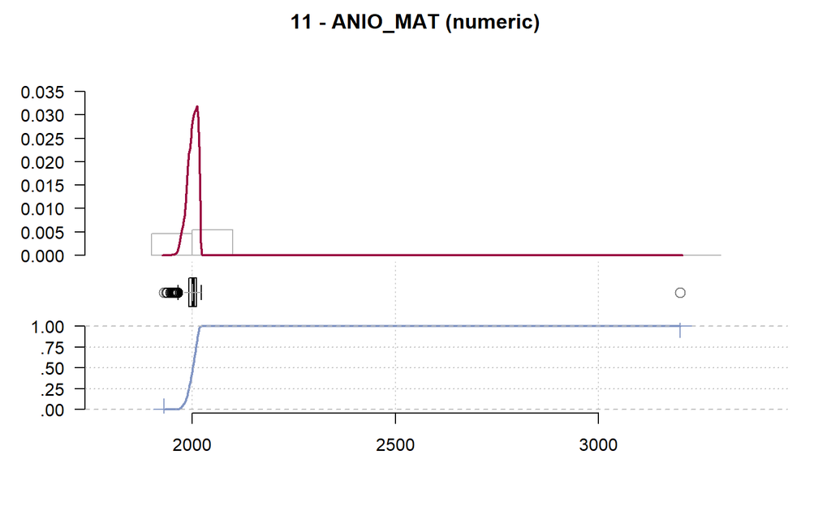

```
## ------------------------------------------------------------------------------
## 12 - anios_casados (numeric)
##
##     length       n    NAs  unique     0s    mean    meanCI'
##     31'700  30'963    737      78     76   19.16     19.00
##              97.7%   2.3%           0.2%             19.31
##
##        .05     .10    .25  median    .75     .90       .95
##       3.00    5.00   9.00   17.00  27.00   36.00     43.00
##
##      range      sd  vcoef     mad    IQR    skew      kurt
##   1'271.00   13.96   0.73   13.34  18.00  -20.11  1'768.46
##
## lowest : -1'182.0, 0.0 (76), 1.0 (349), 2.0 (657), 3.0 (899)
## highest: 75.0, 80.0, 81.0, 82.0, 89.0
##
## ' 95%-CI (classic)
```

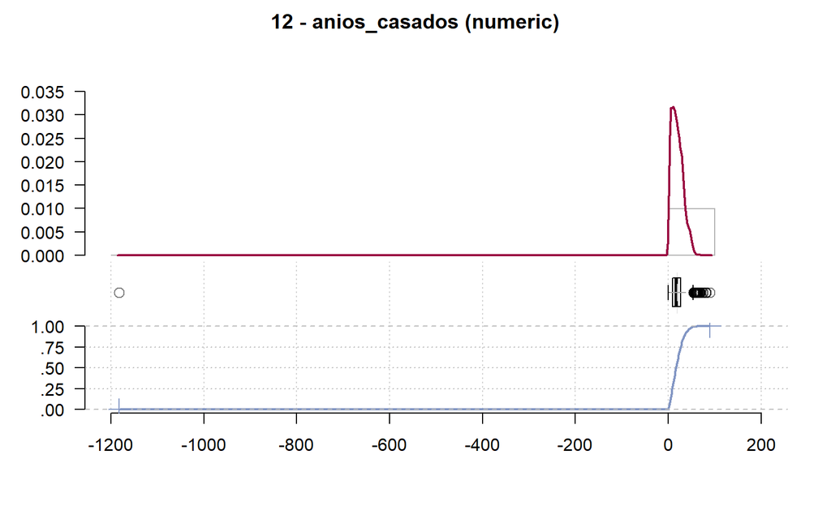

```r
# install.packages("DataExplorer")
library(DataExplorer)

create_report(df_divorcios)
```

[output not shown]

[output not shown]

[output not shown]

[output not shown]

[output not shown]

[output not shown]

[output not shown]

[output cut: 8 more lines]

[output not shown]

[output not shown]

[output not shown]

```
##
## Output created: report.html
```

# Práctica

1. Trabajemos con los datos sobre delitos 2019 en CABA. En principio, poné en práctica algunos de los reportes que presentamos en la clase para conocer la estructura y los datos válidos del DF.

```r
# Defino la clase de hoy y levanto la data
clase <- "clase4"
delitos <-read.csv(paste0("../data/", clase, "/delitos_2019.csv"))
```

2. Obtené la distribución de frecuencias para la variable tipo de delito.
3. Si en la consigna anterior utilizaste janitor, en este punto obtené la distribución de frecuencias con funciones de Rbase.De lo contrario, aplica ahora el paquete janitor.
4. Obtene el promedio de delitos por barrio y ordenalos en sentido descendente.
5. Visualiza en un histograma la distribución de robos según hora del suceso. Es probable que debas chequear los tipos de variables antes de visualizar.